# DM Project

# Student’s Adaptability Level in Online Education

## 1. The Problem

The recent rise in usage of online education has brought up the problem of students’ adaptability level. In this project, we aim to analyze and understand what attributes factor in the rate of adaptivity level in the hope of helping institutes along with students to develop strategies to enhance adaptability.

## 2. Data Mining Task

This project addresses the problem of students’ adaptability in online education using two data mining tasks: classification and clustering. The classification task will predict and classify students using our class label “Adaptivity Level” into adaptability levels (“High”, “Moderate”, “Low”). The clustering task will present clusters of students based on shared characteristics, which will be used to predict new students’ adaptability levels.

## 3. Data

### 3.1 Source

The dataset was obtained from Kaggle.  
https://www.kaggle.com/datasets/mdmahmudulhasansuzan/students-adaptability-level-in-online-education

### 3.2 General information

Our dataset has 14 attributes and 1,205 objects.  
The class label is “Adaptivity Level”.

### 3.3 Attributes characteristics

| Attribute Name | Attribute Type | Description | Possible Values |
| --- | --- | --- | --- |
| Gender | Binary | Student’s gender type | Girl, Boy |
| Age | Ordinal | Student’s age range | 1-5, 6-10, 11-15, 16-20, 21-25, 26-30 |
| Educational Level | Nominal | Student’s education institution level | School, College, University |
| Institution Type | Binary | Student’s education institution type | Government, Non-government |
| IT Student | Binary | Whether the student is studying IT or not | Yes, No |
| Location | Binary | Whether the student is studying in their hometown | Yes, No |
| Load-shedding | Binary | Level of load-shedding | High, Low |
| Financial Condition | Ordinal | Student’s family’s financial condition | Rich, Mid, Poor |
| Internet Type | Binary | Student’s most used internet type | Wifi, Mobile Data |
| Network Type | Ordinal | Network connectivity type | 2G, 3G, 4G |
| Class Duration | Ordinal | Student’s daily class duration in hours | 0, 1-3, 3-6 |
| Self LMS | Binary | Whether the student’s institution has its own LMS | Yes, No |
| Device | Nominal | Student’s most used device in class | Computer, Tab, Mobile |
| Adaptivity Level | Ordinal | Student’s adaptibility level to online education | High, Moderate, Low |

## 4. Data Summarization and Preprocessing:

### 4.1 Installing the packages:

```r
install.packages("dplyr")
install.packages("farver")
install.packages("ggplot2")
install.packages("colorspace")
install.packages("scatterplot3d")
install.packages("gridExtra")
install.packages("superml")
install.packages('party')
install.packages("rpart")
install.packages("rpart.plot")
install.packages("rattle")
install.packages("NbClust")
install.packages("C50")
```

### 4.2 Reading libraries and the dataset:

```r
library(rpart)
library(rpart.plot)
library(rattle)
library(rpart.plot)
library(RColorBrewer)
library(scatterplot3d)
library(ggplot2)
library(dplyr)
library(readr)
library(gridExtra)
library('superml')
library(caret)
library(party)
library(fpc)
library(FSelector)
library(cluster)
library(factoextra)
library('DPBBM')
library("NbClust")
library("C50")
```

```r
dataset <- read_csv("Dataset/students_adaptability_level_online_education.csv")
```

### 4.3 Sample and summary of raw dataset:

```r
View(dataset)

shape<-dim(dataset)
row<-shape[1]
col<-shape[2]
cat("Number of instances:", row, "\n")
```

```
Number of instances: 1205
```

```r
cat("Number of attributes:", col, "\n")
```

```
Number of attributes: 14
```

```r
summary(dataset)
```

```
    Gender              Age            Education Level    Institution Type    IT Student          Location
 Length:1205        Length:1205        Length:1205        Length:1205        Length:1205        Length:1205
 Class :character   Class :character   Class :character   Class :character   Class :character   Class :character
 Mode  :character   Mode  :character   Mode  :character   Mode  :character   Mode  :character   Mode  :character
 Load-shedding      Financial Condition Internet Type      Network Type       Class Duration       Self Lms
 Length:1205        Length:1205         Length:1205        Length:1205        Length:1205        Length:1205
 Class :character   Class :character    Class :character   Class :character   Class :character   Class :character
 Mode  :character   Mode  :character    Mode  :character   Mode  :character   Mode  :character   Mode  :character
    Device          Adaptivity Level
 Length:1205        Length:1205
 Class :character   Class :character
 Mode  :character   Mode  :character
```

```r
names(dataset)
```

```
 [1] "Gender"              "Age"                 "Education Level"     "Institution Type"    "IT Student"
 [6] "Location"            "Load-shedding"       "Financial Condition" "Internet Type"       "Network Type"
[11] "Class Duration"      "Self Lms"            "Device"              "Adaptivity Level"
```

```r
str(dataset)
```

```
spc_tbl_ [1,205 × 14] (S3: spec_tbl_df/tbl_df/tbl/data.frame)
 $ Gender             : chr [1:1205] "Boy" "Girl" "Girl" "Girl" ...
 $ Age                : chr [1:1205] "21-25" "21-25" "16-20" "11-15" ...
 $ Education Level    : chr [1:1205] "University" "University" "College" "School" ...
 $ Institution Type   : chr [1:1205] "Non Government" "Non Government" "Government" "Non Government" ...
 $ IT Student         : chr [1:1205] "No" "No" "No" "No" ...
 $ Location           : chr [1:1205] "Yes" "Yes" "Yes" "Yes" ...
 $ Load-shedding      : chr [1:1205] "Low" "High" "Low" "Low" ...
 $ Financial Condition: chr [1:1205] "Mid" "Mid" "Mid" "Mid" ...
 $ Internet Type      : chr [1:1205] "Wifi" "Mobile Data" "Wifi" "Mobile Data" ...
 $ Network Type       : chr [1:1205] "4G" "4G" "4G" "4G" ...
 $ Class Duration     : chr [1:1205] "3-6" "1-3" "1-3" "1-3" ...
 $ Self Lms           : chr [1:1205] "No" "Yes" "No" "No" ...
 $ Device             : chr [1:1205] "Tab" "Mobile" "Mobile" "Mobile" ...
 $ Adaptivity Level   : chr [1:1205] "Moderate" "Moderate" "Moderate" "Moderate" ...
 - attr(*, "spec")=
  .. cols(
  ..   Gender = col_character(),
  ..   Age = col_character(),
  ..   `Education Level` = col_character(),
  ..   `Institution Type` = col_character(),
  ..   `IT Student` = col_character(),
  ..   Location = col_character(),
  ..   `Load-shedding` = col_character(),
  ..   `Financial Condition` = col_character(),
  ..   `Internet Type` = col_character(),
  ..   `Network Type` = col_character(),
  ..   `Class Duration` = col_character(),
  ..   `Self Lms` = col_character(),
  ..   Device = col_character(),
  ..   `Adaptivity Level` = col_character()
  .. )
 - attr(*, "problems")=<externalptr>
```

### 4.4 Checking for missing values:

```r
sum(is.na(dataset))
```

```
[1] 0
```

Since there are no missing values, and no numerical data to be checked for outliers, and all attributes are of type char, we can’t calculate variance or do discretization.

### 4.5 Plotting Methods:

#### 4.5.1 Bar plot of the gender, age, and education level attributes:

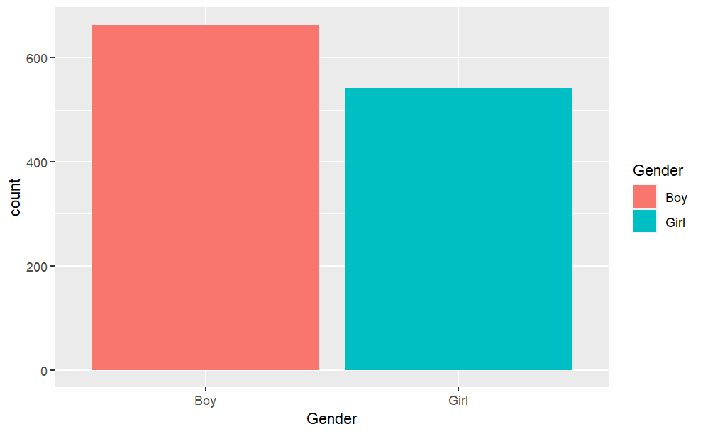

```r
# Bar plot of the gender attribute
ggplot(dataset, mapping = aes(x = Gender)) +
  geom_bar(aes(fill = Gender), position = "dodge")
```

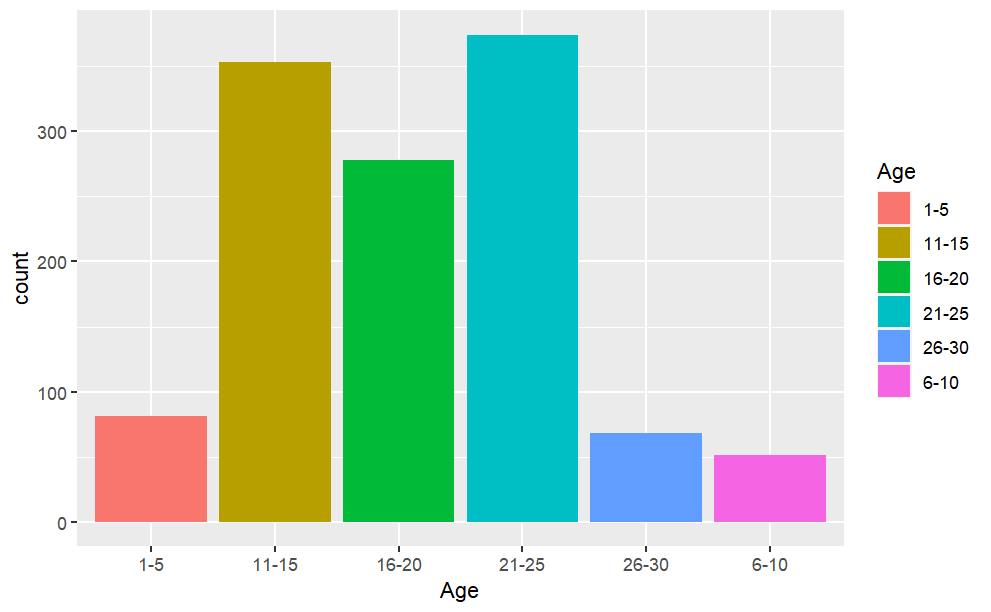

```r
# Bar plot of the age attribute
ggplot(dataset, mapping = aes(x = Age)) +
  geom_bar(aes(fill = Age), position = "dodge")
```

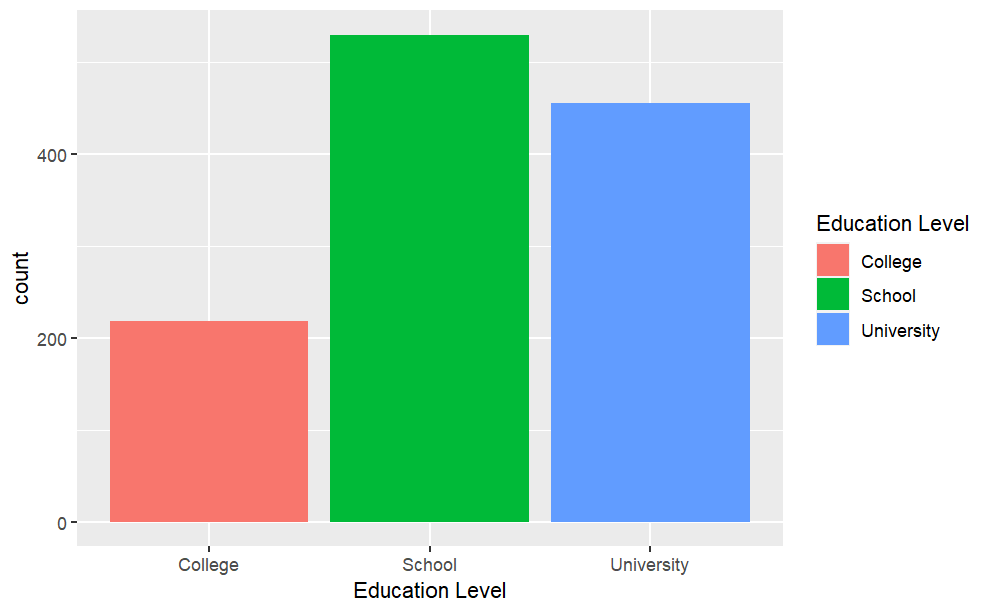

```r
# Bar plot of the education level attribute
ggplot(dataset, mapping = aes(x = `Education Level`)) +
  geom_bar(aes(fill = `Education Level`), position = "dodge")
```

Graphs descriptions:

Gender plot: this graph shows us that the number of students who are boys are slightly more than the girl students.

Age plot: this graph shows us the number of students whose data been collected based on their age range, we noticed they are mostly between the ages of 21-25 and 11-15.

Education level plot: this graph shows us that the dataset is mostly collected from school and university students, and only a small number was collected from college students.

#### 4.5.2 Mosaic plot of the educational level attribute with the financial condition:

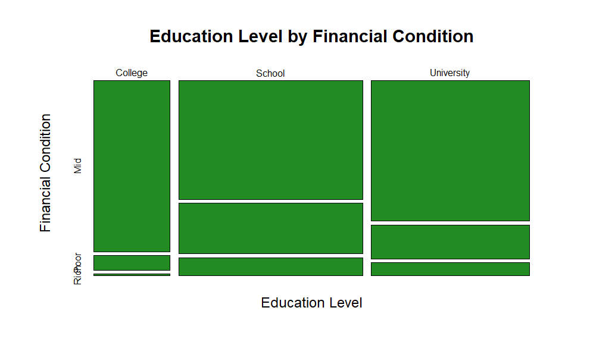

```r
#Mosaic plot of the educational level attribute with the financial condition
counts <- table(dataset$'Education Level', dataset$'Financial Condition')
mosaicplot(counts, xlab='Education Level', ylab='Financial Condition',
           main='Education Level by Financial Condition', col='forestgreen')
```

Graph description: this graph shows us a visual comparison between students’ financial condition against there education level, we noticed that in each education level category, students mostly come from a middle-class family regarding their financial condition.

#### 4.5.3 Pie chart for the self-LMS, IT student, and the adaptivity level attributes:

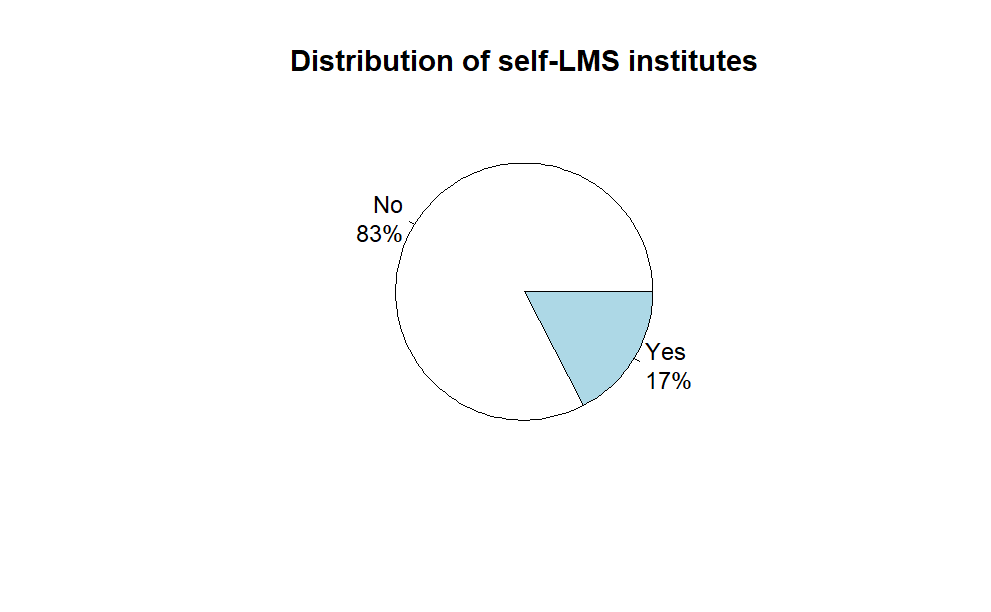

```r
# Pie chart for the self-LMS attribute
tab <- dataset$'Self Lms'%>% table()
precentages <- tab %>% prop.table() %>% round(2) * 100
txt <- paste0(names(tab), '\n', precentages, '%')
pie(tab, labels=txt, main = "Distribution of self-LMS institutes")
```

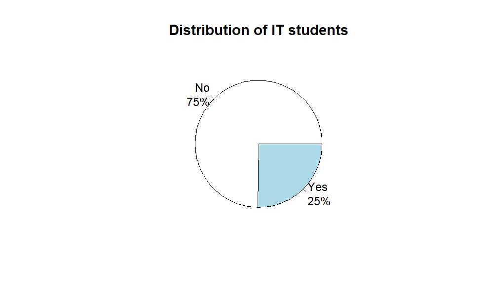

```r
# Pie chart for the IT student attribute
tab <- dataset$'IT Student'%>% table()
precentages <- tab %>% prop.table() %>% round(2) * 100
txt <- paste0(names(tab), '\n', precentages, '%')
pie(tab, labels=txt, main = "Distribution of IT students")
```

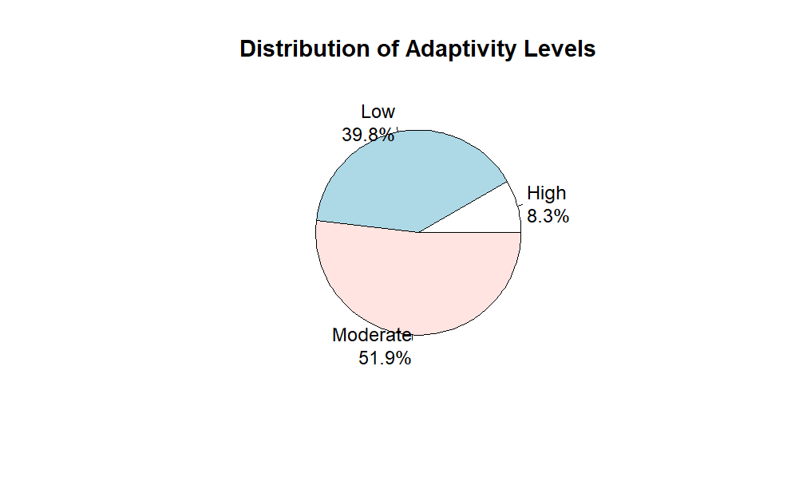

```r
# Pie chart for the adaptivity level attribute
tab <- dataset$'Adaptivity Level' %>% table()
percentages <- tab %>% prop.table() %>% round(3) * 100
txt <- paste0(names(tab), '\n', percentages, '%')
pie(tab, labels = txt, main = "Distribution of Adaptivity Levels")
```

Graphs descriptions:

Self-LMS chart: the graph shows us the percentage of institutions that has their own LMS, we notice that most of them, by a 83% percentage, do not have their own.

IT-Student chart: the graph shows us the percentage of students who are studying IT, we notice that most of them, by a 75% percentage, are not.

Adaptivity level chart: the graphs shows us the percentages of students adaptivity level in online education, which is our class label, we notice that most of them, by a 51.9% percentage, have a moderate adaptivity level, 39.8% have a low adaptivity level, and only 8.3% have a high adaptivity level.

Since this dataset only contains categorical data, discreization and normalization cannot be performed.

### 4.6 Encoding categorical variables:

```r
# Encoding categorical attributes
categorical_cols <- dataset %>%
  select_if(is.character) %>%
  names()
categorical_cols
```

[output not shown]

```r
# Convert categorical columns to factors
dataset[categorical_cols] <- lapply(dataset[categorical_cols], as.factor)
```

### 4.7 Chi Square:

```r
chisq.test(dataset$`Institution Type`, dataset$`Financial Condition`)
```

```
    Pearson's Chi-squared test

data:  dataset$`Institution Type` and dataset$`Financial Condition`
X-squared = 6.0127, df = 2, p-value = 0.04947
```

since the p value is less than 0.05, therefore, the institution type depends on the financial condition.

### 4.8 Balancing the dataset:

Since we can clearly see that the dataset is imbalanced from the piechart provided above, we must take action and balance the dataset, we therefore chose to over-sample the dataset by increasing instances were the class label result is “High”, we will x4 its rows to achieve this.

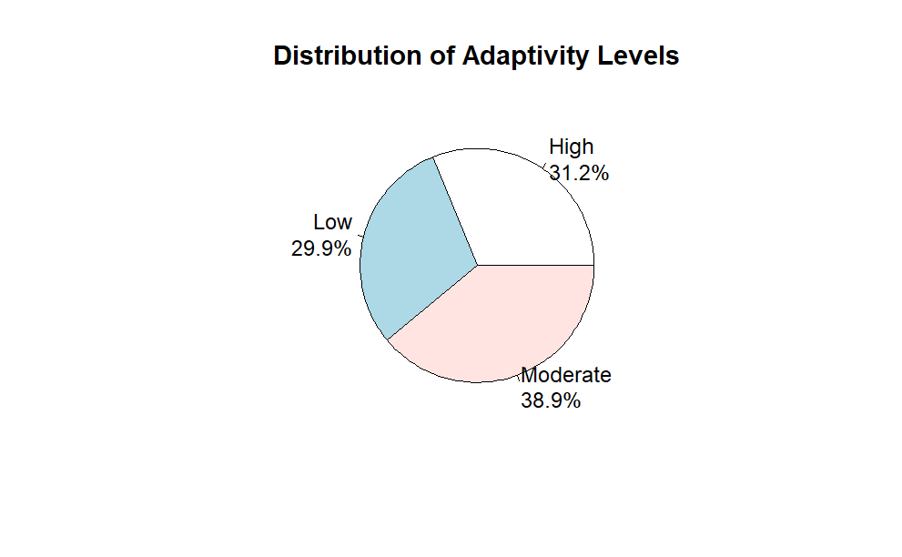

```r
colnames(dataset) <- make.names(colnames(dataset))

# Selecting the High rows so we can triple them
high_rows <- dataset[dataset$Adaptivity.Level == "High", ]

# Triplicate the 'High' rows
triplicated_high_rows <- high_rows[rep(seq_len(nrow(high_rows)), each = 4), ]

# Combine the original dataset with the triplicated 'High' rows
balancedDataset <- rbind(dataset, triplicated_high_rows)

tab <- balancedDataset$Adaptivity.Level %>% table()
percentages <- tab %>% prop.table() %>% round(3) * 100
txt <- paste0(names(tab), '\n', percentages, '%')
pie(tab, labels = txt, main = "Distribution of Adaptivity Levels")
```

```r
shape<-dim(balancedDataset)
row<-shape[1]
cat("Number of instances:", row)
```

```
Number of instances: 1605
```

As we can see, the dataset looks so much better now and is nearly perfectly balanced, after adding 4 times the original amount of rows with “High” adaptivity level, with the total of 1605 instances instead of the previous 1205.

## 5. Data Mining Techniques:

### 5.1 Classification:

We will be dividing the dataset three times by 3 different distributions into two set, one for training the model, and the other is to test it, the distributions were 90/10, 80/20, and 70/30, with the training test having the bigger percentage in all distributions.

The choice of dividing the dataset into three different distributions (90/10, 80/20, and 70/30) reflects a deliberate strategy to explore varying proportions of training and testing data. Each distribution represents a trade-off between the amount of data available for training, crucial for the model to learn patterns effectively, and the amount reserved for testing, essential for evaluating the model’s performance on unseen data. The 90/10 distribution allocates a substantial portion for training, enabling the model to capture intricate patterns in the data. The 80/20 distribution strikes a balance, providing a diverse training set while maintaining a sizable testing set. The 70/30 distribution allows for a more comprehensive evaluation, with a substantial proportion dedicated to testing. This systematic exploration across distributions aims to discern how the model generalizes across varying amounts of training data and assesses its robustness under different scenarios. The chosen distributions provide a nuanced perspective on the model’s performance, aiding in comprehensive insights and informed decision-making.

We will also be using 3 different evaluation metrics, Information Gain, Gain Ratio, and Gini Index.

Information Gain is a measure that quantifies the reduction in uncertainty about the target variable achieved by splitting the data based on a particular feature. The goal of a decision tree is to select the feature that provides the highest information gain, as it leads to more effective classification. Information gain is calculated by comparing the entropy (or impurity) of the dataset before and after the split. We will be using rpart to achieve this.

Gain Ratio is an extension of Information Gain that takes into account the intrinsic information of a feature, preventing bias towards features with many values. Gain Ratio is computed by dividing the Information Gain by the split information, which measures the potential information provided by a feature. We will be using C5.0 to achieve this.

Gini Index is another impurity measure used in decision trees. It quantifies the probability of incorrectly classifying a randomly chosen element in the dataset. The Gini Index is minimized when a node is pure, meaning all instances belong to a single class. Decision trees aim to select splits that minimize the Gini Index, leading to nodes that are as homogenous as possible. We will be using rpart to achieve this.

Splitting the data into training and testing tests

```r
set.seed(1234)
split80 <- createDataPartition(balancedDataset$Adaptivity.Level, p = 0.8, list = FALSE, times = 1)
trainData <- balancedDataset[split80,]
testData <- balancedDataset[split80,]
```

Building decision tress for each attribute selection measure:

```r
infoGainTree <- rpart(formula = Adaptivity.Level ~ ., data = trainData, method = "class", parms = list(split = "information"))
gainRatioTree <- C5.0(Adaptivity.Level ~ ., data = trainData)
GiniIndexTree <- rpart(formula = Adaptivity.Level ~ ., data = trainData, method = "class", parms = list(split = "gini"))
```

1. Information Gain

```r
IG1.ctree <- ctree(infoGainTree, data = trainData)
table(predict(IG1.ctree), trainData$Adaptivity.Level)
```

```
           High Low Moderate
  High      437  24       88
  Low         0 325       71
  Moderate   13  83      404
```

```r
print(IG1.ctree)
```

```
     Conditional inference tree with 35 terminal nodes

Response:  Adaptivity.Level
Inputs:  Gender, Age, Education.Level, Institution.Type, IT.Student, Location, Load.shedding, Financial.Condition, Internet.Type, Network.Type, Class.Duration, Self.Lms, Device
Number of observations:  1445

1) Financial.Condition == {Mid, Poor}; criterion = 1, statistic = 382.189
  2) Class.Duration == {1-3, 3-6}; criterion = 1, statistic = 259.706
    3) Age == {6-10}; criterion = 1, statistic = 191.829
      4)*  weights = 57
    3) Age == {1-5, 11-15, 16-20, 21-25, 26-30}
      5) Age == {11-15, 21-25, 26-30}; criterion = 1, statistic = 108.605
        6) Network.Type == {4G}; criterion = 1, statistic = 108.053
          7) Gender == {Girl}; criterion = 1, statistic = 91.093
            8) Institution.Type == {Non Government}; criterion = 1, statistic = 43.654
              9) Load.shedding == {High}; criterion = 1, statistic = 42.02
                10)*  weights = 14
              9) Load.shedding == {Low}
                11)*  weights = 58
            8) Institution.Type == {Government}
              12) Education.Level == {University}; criterion = 0.998, statistic = 17.967
                13)*  weights = 23
              12) Education.Level == {College, School}
                14)*  weights = 7
          7) Gender == {Boy}
            15) Class.Duration == {3-6}; criterion = 1, statistic = 69.559
              16) IT.Student == {Yes}; criterion = 1, statistic = 17.155
                17)*  weights = 23
              16) IT.Student == {No}
                18)*  weights = 33
            15) Class.Duration == {1-3}
              19) Self.Lms == {Yes}; criterion = 1, statistic = 55.447
                20)*  weights = 94
              19) Self.Lms == {No}
                21) Load.shedding == {Low}; criterion = 1, statistic = 54.652
                  22) IT.Student == {Yes}; criterion = 1, statistic = 43.172
                    23)*  weights = 32
                  22) IT.Student == {No}
                    24) Age == {11-15, 26-30}; criterion = 1, statistic = 29.27
                      25)*  weights = 148
```

[output cut: 54 more lines]

```
                61)*  weights = 7
            58) Load.shedding == {High}
              62)*  weights = 15
          57) Self.Lms == {Yes}
            63)*  weights = 9
  2) Class.Duration == {0}
    64)*  weights = 133
1) Financial.Condition == {Rich}
  65) Age == {11-15, 21-25, 26-30, 6-10}; criterion = 1, statistic = 97.467
    66)*  weights = 209
  65) Age == {1-5, 16-20}
    67) Location == {No}; criterion = 0.996, statistic = 16.15
      68)*  weights = 10
    67) Location == {Yes}
      69)*  weights = 10
```

[figure not shown]

```r
plot(IG1.ctree, type="simple")
```

```r
testPred <- predict(IG1.ctree, newdata = testData)
result<-table(testPred, testData$Adaptivity.Level)

results <- confusionMatrix(testPred, testData$Adaptivity.Level)
print(results)
```

```
Confusion Matrix and Statistics

          Reference
Prediction High Low Moderate
  High      437  24       88
  Low         0 325       71
  Moderate   13  83      404

Overall Statistics

               Accuracy : 0.8069
                 95% CI : (0.7856, 0.827)
    No Information Rate : 0.3896
    P-Value [Acc > NIR] : < 2.2e-16

                  Kappa : 0.7096

 Mcnemar's Test P-Value : < 2.2e-16

Statistics by Class:

                     Class: High Class: Low Class: Moderate
Sensitivity               0.9711     0.7523          0.7176
Specificity               0.8874     0.9299          0.8912
Pos Pred Value            0.7960     0.8207          0.8080
Neg Pred Value            0.9855     0.8980          0.8317
Prevalence                0.3114     0.2990          0.3896
Detection Rate            0.3024     0.2249          0.2796
Detection Prevalence      0.3799     0.2740          0.3460
Balanced Accuracy         0.9293     0.8411          0.8044
```

```r
confusion_matrix <- confusionMatrix(data = testPred, reference = testData$Adaptivity.Level)

# Calculate precision
precision <- confusion_matrix$table[2,2] / sum(confusion_matrix$table[,2])
cat("Precision:", precision, "\n")
```

```
Precision: 0.7523148
```

Model Analysis:

This tree shows that the most influential attribute for identifying the Adaptivity Level is the Financial Condition, it suggests that the first split is based on the financial condition being either “Mid” or “Poor.” The subsequent splits are Class Duration being either “1-3” and “3-6”, and then Age.

2. Gain Ratio

```r
# Make predictions on the training set
trainPred <- predict(gainRatioTree, newdata = trainData)

# Display the confusion matrix for training data
trainResults <- confusionMatrix(trainPred, trainData$Adaptivity.Level)
print(trainResults)
```

```
Confusion Matrix and Statistics

          Reference
Prediction High Low Moderate
  High      450   9       47
  Low         0 399       38
  Moderate    0  24      478

Overall Statistics

               Accuracy : 0.9183
                 95% CI : (0.903, 0.9319)
    No Information Rate : 0.3896
    P-Value [Acc > NIR] : < 2.2e-16

                  Kappa : 0.8772

 Mcnemar's Test P-Value : 8.88e-13

Statistics by Class:

                     Class: High Class: Low Class: Moderate
Sensitivity               1.0000     0.9236          0.8490
Specificity               0.9437     0.9625          0.9728
Pos Pred Value            0.8893     0.9130          0.9522
Neg Pred Value            1.0000     0.9673          0.9099
Prevalence                0.3114     0.2990          0.3896
Detection Rate            0.3114     0.2761          0.3308
Detection Prevalence      0.3502     0.3024          0.3474
Balanced Accuracy         0.9719     0.9430          0.9109
```

[figure not shown]

```r
# Make predictions on the test set
testPred <- predict(gainRatioTree, newdata = testData)

# Display the confusion matrix for test data
testResults <- confusionMatrix(testPred, testData$Adaptivity.Level)

# Plot the decision tree
plot(gainRatioTree)
```

```r
summary(gainRatioTree)
```

```
Call:
C5.0.formula(formula = Adaptivity.Level ~ ., data = trainData)


C5.0 [Release 2.07 GPL Edition]     Sat Dec  2 23:16:26 2023
-------------------------------

Class specified by attribute `outcome'

Read 1445 cases (14 attributes) from undefined.data

Decision tree:

Class.Duration = 0: Low (134/9)
Class.Duration in {1-3,3-6}:
:...Financial.Condition = Rich:
    :...Age = 1-5: Low (3)
    :   Age in {11-15,16-20,21-25,26-30,6-10}:
    :   :...Internet.Type = Mobile Data:
    :       :...Gender = Girl: High (9)
    :       :   Gender = Boy:
    :       :   :...Age in {11-15,21-25,26-30,6-10}: High (25/7)
    :       :       Age = 16-20: Moderate (7)
    :       Internet.Type = Wifi:
    :       :...Network.Type in {2G,3G}: High (24)
    :           Network.Type = 4G:
    :           :...Age = 16-20: High (0)
    :               Age = 11-15:
    :               :...Gender = Boy: High (4)
    :               :   Gender = Girl: Moderate (8/2)
    :               Age in {21-25,26-30,6-10}:
    :               :...Institution.Type = Government: High (37)
    :                   Institution.Type = Non Government:
    :                   :...Self.Lms = Yes: High (23)
    :                       Self.Lms = No:
    :                       :...IT.Student = Yes:
    :                           :...Gender = Boy: Low (3)
    :                           :   Gender = Girl: High (16/3)
    :                           IT.Student = No:
    :                           :...Class.Duration = 1-3:
```

[output cut: 201 more lines]

```
     90.73% Age
     90.73% Financial.Condition
     74.95% Network.Type
     65.12% Gender
     53.15% Institution.Type
     48.37% Self.Lms
     35.50% IT.Student
     33.08% Internet.Type
     28.03% Load.shedding
     24.43% Location
     22.35% Device
     11.70% Education.Level


Time: 0.0 secs
```

```r
confusion_matrix <- confusionMatrix(data = testPred, reference = testData$Adaptivity.Level)

# Calculate precision
precision <- confusion_matrix$table[2,2] / sum(confusion_matrix$table[,2])
cat("Precision:", precision, "\n")
```

```
Precision: 0.9236111
```

Model Analysis:

3. Gini Index

```r
GI1.ctree <- ctree(GiniIndexTree, data = trainData)
table(predict(GI1.ctree), trainData$Adaptivity.Level)
```

```
           High Low Moderate
  High      437  24       88
  Low         0 325       71
  Moderate   13  83      404
```

```r
print(GI1.ctree)
```

```
     Conditional inference tree with 35 terminal nodes

Response:  Adaptivity.Level
Inputs:  Gender, Age, Education.Level, Institution.Type, IT.Student, Location, Load.shedding, Financial.Condition, Internet.Type, Network.Type, Class.Duration, Self.Lms, Device
Number of observations:  1445

1) Financial.Condition == {Mid, Poor}; criterion = 1, statistic = 382.189
  2) Class.Duration == {1-3, 3-6}; criterion = 1, statistic = 259.706
    3) Age == {6-10}; criterion = 1, statistic = 191.829
      4)*  weights = 57
    3) Age == {1-5, 11-15, 16-20, 21-25, 26-30}
      5) Age == {11-15, 21-25, 26-30}; criterion = 1, statistic = 108.605
        6) Network.Type == {4G}; criterion = 1, statistic = 108.053
          7) Gender == {Girl}; criterion = 1, statistic = 91.093
            8) Institution.Type == {Non Government}; criterion = 1, statistic = 43.654
              9) Load.shedding == {High}; criterion = 1, statistic = 42.02
                10)*  weights = 14
              9) Load.shedding == {Low}
                11)*  weights = 58
            8) Institution.Type == {Government}
              12) Education.Level == {University}; criterion = 0.998, statistic = 17.967
                13)*  weights = 23
              12) Education.Level == {College, School}
                14)*  weights = 7
          7) Gender == {Boy}
            15) Class.Duration == {3-6}; criterion = 1, statistic = 69.559
              16) IT.Student == {Yes}; criterion = 1, statistic = 17.155
                17)*  weights = 23
              16) IT.Student == {No}
                18)*  weights = 33
            15) Class.Duration == {1-3}
              19) Self.Lms == {Yes}; criterion = 1, statistic = 55.447
                20)*  weights = 94
              19) Self.Lms == {No}
                21) Load.shedding == {Low}; criterion = 1, statistic = 54.652
                  22) IT.Student == {Yes}; criterion = 1, statistic = 43.172
                    23)*  weights = 32
                  22) IT.Student == {No}
                    24) Age == {11-15, 26-30}; criterion = 1, statistic = 29.27
                      25)*  weights = 148
```

[output cut: 54 more lines]

```
                61)*  weights = 7
            58) Load.shedding == {High}
              62)*  weights = 15
          57) Self.Lms == {Yes}
            63)*  weights = 9
  2) Class.Duration == {0}
    64)*  weights = 133
1) Financial.Condition == {Rich}
  65) Age == {11-15, 21-25, 26-30, 6-10}; criterion = 1, statistic = 97.467
    66)*  weights = 209
  65) Age == {1-5, 16-20}
    67) Location == {No}; criterion = 0.996, statistic = 16.15
      68)*  weights = 10
    67) Location == {Yes}
      69)*  weights = 10
```

[figure not shown]

```r
plot(GI1.ctree, type="simple")
```

```r
testPred <- predict(GI1.ctree, newdata = testData)
result<-table(testPred, testData$Adaptivity.Level)

results <- confusionMatrix(testPred, testData$Adaptivity.Level)
print(results)
```

```
Confusion Matrix and Statistics

          Reference
Prediction High Low Moderate
  High      437  24       88
  Low         0 325       71
  Moderate   13  83      404

Overall Statistics

               Accuracy : 0.8069
                 95% CI : (0.7856, 0.827)
    No Information Rate : 0.3896
    P-Value [Acc > NIR] : < 2.2e-16

                  Kappa : 0.7096

 Mcnemar's Test P-Value : < 2.2e-16

Statistics by Class:

                     Class: High Class: Low Class: Moderate
Sensitivity               0.9711     0.7523          0.7176
Specificity               0.8874     0.9299          0.8912
Pos Pred Value            0.7960     0.8207          0.8080
Neg Pred Value            0.9855     0.8980          0.8317
Prevalence                0.3114     0.2990          0.3896
Detection Rate            0.3024     0.2249          0.2796
Detection Prevalence      0.3799     0.2740          0.3460
Balanced Accuracy         0.9293     0.8411          0.8044
```

```r
confusion_matrix <- confusionMatrix(data = testPred, reference = testData$Adaptivity.Level)

# Calculate precision
precision <- confusion_matrix$table[2,2] / sum(confusion_matrix$table[,2])
cat("Precision:", precision, "\n")
```

```
Precision: 0.7523148
```

Model Analysis:

This tree shows the exact same results as the Information Gain tree, it shows that the most influential attribute for identifying the Adaptivity Level is the Financial Condition, it suggests that the first split is based on the financial condition being either “Mid” or “Poor.” The subsequent splits are Class Duration being either “1-3” and “3-6”, and then Age.